- **L3 MIASHS/Ingémath/METIS**
- **[Université Paris Cité](https://www.u-paris.fr)**
- [Course Homepage](https://bgentou.github.io/MA15E045/)

# Examen du 4 juin 2026 (3H)

## Exercice 1

Voici le modèle relationnel d’une partie de la base de données d’une chaîne de cinémas.

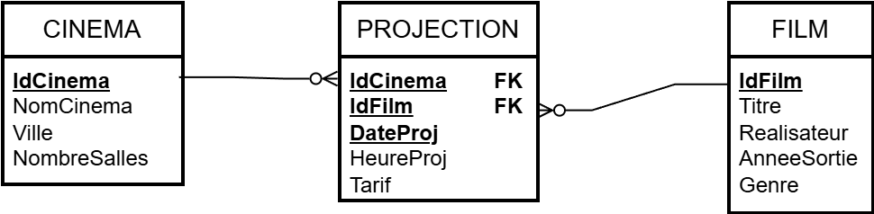

Écrire les requêtes SQL permettant de répondre aux questions suivantes.

1. Afficher la liste des films (Titre, Réalisateur) du genre ‘Science-Fiction’ sortis après 2020, classés du plus récent au plus ancien.

**TipSolution**

```sql
SELECT Titre, Realisateur
FROM FILM
WHERE Genre = 'Science-Fiction' AND AnneeSortie > 2020
ORDER BY AnneeSortie DESC;
```

2. Afficher le nom et la ville des cinémas qui possèdent strictement plus de 8 salles.

**TipSolution**

```sql
SELECT NomCinema, Ville
FROM CINEMA
WHERE NombreSalles > 8;
```

3. Afficher sans doublons les titres des films projetés le `2026-05-25` et le nom du cinéma où ils ont été projetés.

**TipSolution**

```sql
SELECT DISTINCT F.Titre, C.NomCinema
FROM PROJECTION P
JOIN FILM F ON P.IdFilm = F.IdFilm
JOIN CINEMA C ON P.IdCinema = C.IdCinema
WHERE P.DateProj = '2026-05-25';
```

4. Calculer pour chaque cinéma, le prix moyen du tarif des projections (afficher l’attribut `NomCinema` et la moyenne calculée).

**TipSolution**

```sql
SELECT C.NomCinema, AVG(P.Tarif) AS TarifMoyen
FROM PROJECTION P
JOIN CINEMA C ON P.IdCinema = C.IdCinema
GROUP BY C.IdCinema, C.NomCinema;
```

5. Compter le nombre total de projections réalisées pour le film dont le titre est ‘Inception’.

**TipSolution**

```sql
SELECT COUNT(*) AS NbProjections
FROM PROJECTION P
JOIN FILM F ON P.IdFilm = F.IdFilm
WHERE F.Titre = 'Inception';
```

6. Afficher sans doublons les cinémas (Nom et Ville) qui ont programmé au moins un film réalisé par ‘Christopher Nolan’.

**TipSolution**

```sql
SELECT DISTINCT C.NomCinema, C.Ville
FROM PROJECTION P
JOIN CINEMA C ON P.IdCinema = C.IdCinema
JOIN FILM F ON P.IdFilm = F.IdFilm
WHERE F.Realisateur = 'Christopher Nolan';
```

7. Afficher, la liste des films (Titre, Genre) qui n’ont **jamais** été projetés dans aucun cinéma.

   **Ecrire obligatoirement** 2 versions :
   - une première sans sous-requête ou CTE,
   - une seconde avec une sous-requête ou CTE.

**TipSolution**

```sql
-- Version a : sans sous-requête avec LEFT JOIN
SELECT Titre, Genre
FROM FILM F LEFT JOIN PROJECTION P ON F.IdFilm = P.IdFilm
WHERE P.IdFilm IS NULL;
-- Version b : Sous-requête avec NOT IN
SELECT Titre, Genre
FROM FILM
WHERE IdFilm NOT IN (SELECT DISTINCT IdFilm FROM PROJECTION);
```

8. Afficher le nom des cinémas qui ont réalisé **plus de 15 projections** au total, toutes dates confondues.

**TipSolution**

```sql
SELECT C.NomCinema
FROM PROJECTION P
JOIN CINEMA C ON P.IdCinema = C.IdCinema
GROUP BY C.IdCinema, C.NomCinema
HAVING COUNT(*) > 15;
```

9. Afficher les détails de la projection (Nom du cinéma, Titre du film, Tarif) qui correspond au **tarif le plus cher** de toute la base de données.

**TipSolution**

```sql
-- version sans CTE
SELECT C.NomCinema, F.Titre, P.Tarif
FROM PROJECTION P
JOIN CINEMA C ON P.IdCinema = C.IdCinema
JOIN FILM F ON P.IdFilm = F.IdFilm
WHERE P.Tarif = (SELECT MAX(Tarif) FROM PROJECTION);

-- version avec CTE
WITH M AS (SELECT MAX(Tarif) AS MaxTarif FROM PROJECTION)
SELECT C.NomCinema, F.Titre, P.Tarif
FROM PROJECTION P
JOIN CINEMA C ON P.IdCinema = C.IdCinema
JOIN FILM F ON P.IdFilm = F.IdFilm
JOIN P.Tarif = M.MaxTarif;
```

10. Afficher pour chaque ville, le nombre total de films différents qui y ont été projetés.

**TipSolution**

```sql
SELECT C.Ville, COUNT(DISTINCT P.IdFilm) AS NbFilmsDifferents
FROM PROJECTION P
JOIN CINEMA C ON P.IdCinema = C.IdCinema
GROUP BY C.Ville;
```

11. Ecrire en SQL la définition complète de la table PROJECTION.

**TipSolution**

```sql
CREATE TABLE PROJECTION(
   IdCinema INTEGER,
   IdFilm INTEGER,
   DateProj DATE,
   HeureProj TIME,
   Tarif MONEY,
   CONSTRAINT PROJECTION_pk PRIMARY KEY (IdCinema,IdFilm,DateProj),
   CONSTRAINT PROJECTION_CINEMA_fk
      FOREIGN KEY (IdCinema)
      REFERENCES CINEMA(IdCinema),
   CONSTRAINT PROJECTION_FILM_fk
      FOREIGN KEY (IdFilm)
      REFERENCES FILM(IdFilm)
);
```

## Exercice 2

Écrire un diagramme E/A avec les cardinalités pour les consultations d’une clinique vétérinaire dont voici les caractéristiques.

- La clinique emploie des vétérinaires pour lesquels on enregistre un numéro d’employé unique, un nom, un prénom, une spécialité et un numéro de téléphone.
- La clinique reçoit des animaux pour lesquels on enregistre un numéro d’identification unique, un nom, une date de naissance, une espèce (ex: chien, chat), et un poids.
- Chaque animal appartient à un seul propriétaire.
- Pour chaque propriétaire, on enregistre un numéro de client unique, un nom, un prénom, une adresse et un numéro de téléphone.
- Un propriétaire peut posséder plusieurs animaux.
- Pour chaque consultation, on enregistre un numéro de consultation unique, une date et une heure, ainsi que des observations faites par le vétérinaire.
- Une consultation est effectuée par un seul vétérinaire et concerne un seul animal.
- Un animal peut subir plusieurs consultations.
- Pour chaque type d’acte médical pratiqué dans la clinique (ex: vaccination, prise de sang, etc.), on enregistre un code unique, une description et un tarif.
- Si un ou des actes médicaux sont réalisés au cours d’une consultation, on enregistre le type d’acte et la quantité effectuée.
- Il peut y avoir plusieurs types d’actes réalisés au cours d’une même consultation.

**TipSolution**

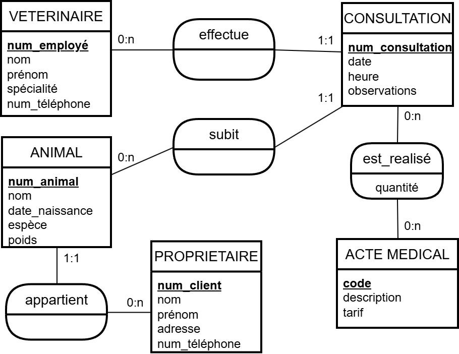

## Exercice 3

On veut créer une BDD pour un réseau social simplifié dans lequel les utilisateurs peuvent :

- s’abonner à un ou plusieurs utilisateurs,
- envoyer des publications,
- envoyer des commentaires sur des publications.

Voici le diagramme E/A qui a été élaboré par l’équipe de conception.

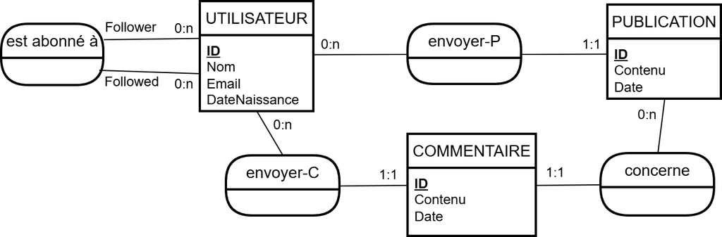

Convertir ce diagramme E/A en un modèle relationnel avec la représentation des cardinalités.

**TipSolution**

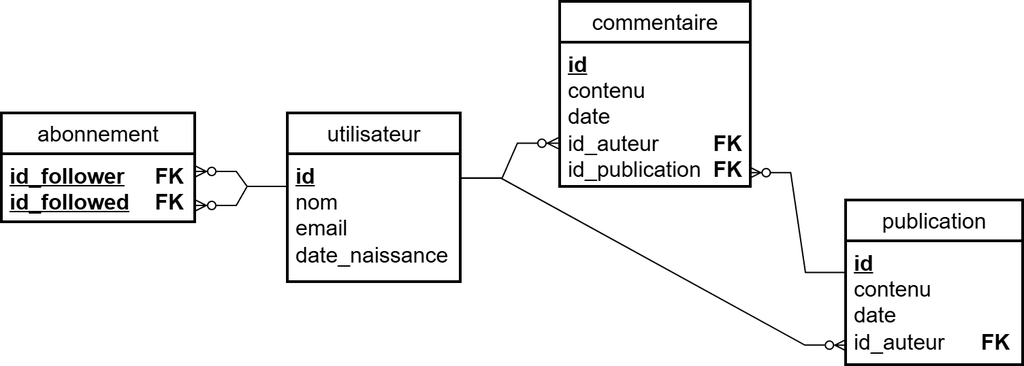

## Exercice 4

On considère la relation RESULTAT suivante qui représente des étudiants, des cours, des enseignants et les notes obtenues :

RESULTAT (NumEtud, NomEtud, NumCours, TitreCours, Note, NumProf, NomProf)

Voici la liste des dépendances fonctionnelles :

```
NumEtud → NomEtud
NumCours → TitreCours, NumProf
NumEtud, NumCours → Note
NumProf → NomProf
```

### Questions

1. Identifier une clé de la relation RESULTAT. Justifier.

**TipSolution**

Considérons $K = \{\text{NumEtud, NumCours}\}$.

La fermeture $K^+$ contient tous les attributs de $R$, ce qui n’est pas vrai pour ses parties $\{\text{NumEtud}\}$ et $\{\text{NumCours}\}$ donc $K$ est une clé de RESULTAT.

Non demandé : Comme NumEtud et NumCours n’apparaissent dans aucun membre de droite d’une DF, une clé de RESULTAT contient nécessairement ces attributs. On en déduit que $K$ est la seule clé de R.

2. Montrer que cette relation n’est pas en Deuxième Forme Normale. Montrer qu’elle n’est pas en Troisième Forme Normale.

**TipSolution**

La relation RESULTAT n’est pas en FN2 car la DF NumEtud → NomEtud implique que $\{\text{NumEtud}\}$ est une partie stricte de la clé $K$ telle que $\{\text{NumEtud}\}^+ \not\subset K$ ce qui nie la règle de la FN2.

Cette relation n’est pas non plus en FN3 puisque tout schéma en FN3 est en FN2. On peut aussi voir par exemple que la DF NumEtud → NomEtud ne respecte pas la règle de la FN3, c’est-à-dire : pour toute DF non triviale, le membre gauche est une sur-clé ou le membre droit fait partie d’une clé.

3. Décomposer la relation en FN3 sans perte de DF et sans perte d’information. Détailler les étapes de la décomposition.

**TipSolution**

On applique l’algorithme de décomposition FN3 sans perte de DF et sans perte d’information vu en cours.

On note $\Sigma$ l’ensemble des DF données. $\Sigma$ est irredondant donc on peut appliquer directement l’algorithme de décomposition vu en cours, on obtient les relations

- Etud(NumEtud, NomEtud), de clé NumEtud,
- Cours(NumCours, TitreCours, NumProf), de clé NumCours,
- Eval(NumEtud, NumCours, Note), de clé $\{\text{NumEtud, NumCours}\}$,
- Prof(NumProf, NomProf), de clé NumProf.

Comme $NumEtud,NumCours$ est une clé pour RESULTAT, il n’est pas nécessaire d’ajouter une relation pour éviter la perte d’information.

- $\pi_{\text{Etud}}(\Sigma)$ est équivalent à $\{\text{NumEtud → NomEtud}\}$, la DF NumEtud → NomEtud vérifie la FN3 et la FNBC pour la relation Etud car le déterminant est une clé de Etud.
- $\pi_{\text{Cours}}(\Sigma)$ est équivalent à $\{\text{NumCours → TitreCours,NumProf}\}$, la DF NumCours→TitreCours,NumProf vérifie la FN3 et la FNBC pour la relation Cours car le déterminant est une clé de Cours.
- $\pi_{\text{Eval}}(\Sigma)$ est équivalent à $\{\text{NumEtud, NumCours → Note}\}$, la DF NumEtud,NumCours → Note vérifie la FN3 et la FNBC pour la relation Eval car le déterminant est une clé de Eval.
- $\pi_{\text{Prof}}(\Sigma)$ est équivalent à $\{\text{NumProf → NomProf}\}$, la DF NumProf → NomProf vérifie la FN3 et la FNBC pour la relation Prof car le déterminant est une clé de Prof.
4. Le schéma obtenu est-il en FNBC ? Justifier.

**TipSolution**

Le schéma est en FNBC (justification dans la question précédente).